# daily tag quicklook update

wrc

2023-09-12

# 1 setup

Run this daily to get a snapshot of tag stats and health

# 2 notes

## 2.1 PATH TO LATEST DATA

```r
# paths to update when you run
portaldir <- "portal_downloads"
datadirss <- list.files(portaldir)
datadir <- file.path(portaldir, datadirss[length(datadirss)])
```

## 2.2 basic helper function

## 2.3 load paths adjust as needed

## 2.4 Import data from wildlife portal and the goniometer. Merge the two stacks.

# 3 tag summary

|  | ptt | hex | serial | tag_model | deployid | catalog_ID_DUML | BRS_season | deploydate_yyyymmdd | deploytime_hhmm | species | location | tagger | permit | tagtype | longitude | latitude | tagside | taglocation | taglocationnotes | programming_basic_descriptor | notes | recorder | age | sex | agesex_conf | headshot | agesex_reason | appearance_notes |
| --- | --- | --- | --- | --- | --- | --- | --- | --- | --- | --- | --- | --- | --- | --- | --- | --- | --- | --- | --- | --- | --- | --- | --- | --- | --- | --- | --- | --- |
| 4 | 220740 | 2C2704C | NA | SPLASH10-333 | ZcTag136_DUML | NA | brs10 | 20230725 | 1321 | Zca | Hat | dlw | NA | NA | NA | NA | L | NA | NA | NA | NA | NA | a | m | high | y | teeth | NA |
| 5 | 220736 | 2C27000 | NA | SPLASH10-333 | ZcTag137_DUML | NA | brs10 | 20230725 | 1449 | Zca | Hat | dlw | NA | NA | NA | NA | L | NA | NA | NA | NA | NA | a | f | high | y | mother calf | NA |
| 6 | 220743 | 2C27079 | NA | SPLASH10-333 | ZcTag138_DUML | NA | brs10 | 20230725 | 1924 | Zca | Hat | dlw | NA | NA | NA | NA | R | NA | NA | NA | NA | NA | a | m | high | y | teeth | NA |
| 1 | 220745 | 2C27098 | NA | SPLASH10-333 | ZcTag139_DUML | NA | brs10 | 20230726 | 1638 | Zca | Hat | dlw | NA | NA | NA | NA | R | NA | NA | NA | NA | NA | u | u |  | y |  | NA |
| 2 | 233112 | 406B18B | NA | SPLASH10-333 | ZcTag140_DUML | NA | brs10 | 20230726 | 1958 | Zca | Hat | dlw | NA | NA | NA | NA | R | NA | NA | NA | NA | NA | a | m | high | y | teeth | NA |
| 3 | 233115 | 406B1BE | NA | SPLASH10-333 | ZcTag141_DUML | NA | brs10 | 20230726 | 2027 | Zca | Hat | dlw | NA | NA | NA | NA | L | NA | NA | NA | NA | NA | a | m | high | y | teeth | NA |
| 9 | 233118 | 406B1E1 | NA | SPLASH10-333 | ZcTag142_DUML | NA | brs10 | 20230807 | 1340 | Zca | Hat | dlw | NA | NA | NA | NA |  | NA | NA | NA | NA | NA |  |  |  |  |  | NA |
| 8 | 233110 | 406B16A | NA | SPLASH10-F-333 | ZcTag143_DUML | NA | brs10 | 20230807 | 1558 | Zca | Hat | dlw | NA | NA | NA | NA |  | NA | NA | NA | NA | NA |  |  |  |  |  | NA |
| 7 | 233111 | 406B179 | NA | SPLASH10-F-333 | ZcTag144_DUML | NA | brs10 | 20230807 | 1620 | Zca | Hat | dlw | NA | NA | NA | NA |  | NA | NA | NA | NA | NA |  |  |  |  |  | NA |
| 10 | 233108 | 406B14C | NA | SPLASH10-F-333 | ZcTag145_DUML | NA | brs10 | 20230821 | 1901 | Zca | Hat | dlw | NA | NA | NA | NA |  | NA | NA | NA | NA | NA |  |  |  |  |  | NA |
| 11 | 233107 | 406B135 | NA | SPLASH10-F-333 | ZcTag146_DUML | NA | brs10 | 20230821 | 1914 | Zca | Hat | dlw | NA | NA | NA | NA |  | NA | NA | NA | NA | NA |  |  |  |  |  | NA |

# 4 calculate stats

# 5 summaries

## 5.1 status and corrupt

|  | deployid | ptt | nmsg | ncrc | transmits | battvoltrange | zerodepthrange | last_sta_recieved | ncorrupt |
| --- | --- | --- | --- | --- | --- | --- | --- | --- | --- |
| 2 | ZcTag136_DUML | 220740 | 108 | 107 | 18120 | 3.248 to 3.568 | -13 to 5 | 2023-09-10 09:45:03 | 306 |
| 1 | ZcTag137_DUML | 220736 | 43 | 38 | 16939 | 3.376 to 3.504 | -10 to 3 | 2023-09-12 14:05:35 | 351 |
| 3 | ZcTag138_DUML | 220743 | 10 | 6 | 871 | 3.568 to 3.568 | 2 to 3 | 2023-08-07 14:30:41 | 334 |
| 4 | ZcTag139_DUML | 220745 | 12 | 12 | 7471 | 3.504 to 3.568 | -37 to 1 | 2023-08-22 15:18:42 | 158 |
| 9 | ZcTag140_DUML | 233112 | 7 | 7 | 1188 | 3.44 to 3.504 | 1 to 3 | 2023-08-02 11:16:31 | 81 |
| 10 | ZcTag141_DUML | 233115 | 16 | 15 | 1702 | 3.504 to 3.504 | 1 to 3 | 2023-07-30 14:31:55 | 52 |
| 11 | ZcTag142_DUML | 233118 | 52 | 50 | 11330 | 3.44 to 3.504 | 3 to 6 | 2023-09-12 12:29:50 | 163 |
| 7 | ZcTag143_DUML | 233110 | 15 | 15 | 10064 | 3.44 to 3.504 | -11 to 3 | 2023-09-12 10:20:33 | 260 |
| 8 | ZcTag144_DUML | 233111 | 4 | 3 | 8041 | 3.44 to 3.44 | 3 to 4 | 2023-09-05 16:21:09 | 438 |
| 6 | ZcTag145_DUML | 233108 | 1 | 0 | 0 |  |  |  | 116 |
| 5 | ZcTag146_DUML | 233107 | 21 | 19 | 3831 | 3.504 to 3.504 | 1 to 4 | 2023-09-11 14:00:39 | 151 |

## 5.2 locations

|  | deployid | ptt | nloc | nz | na | nb | n0 | n1 | n2 | n3 | last_loc_recieved |
| --- | --- | --- | --- | --- | --- | --- | --- | --- | --- | --- | --- |
| 2 | ZcTag136_DUML | 220740 | 795 | 1 | 61 | 173 | 350 | 158 | 41 | 11 | 2023-09-12 14:36:27 |
| 1 | ZcTag137_DUML | 220736 | 660 | 1 | 98 | 218 | 219 | 97 | 21 | 6 | 2023-09-12 14:45:28 |
| 3 | ZcTag138_DUML | 220743 | 213 | 0 | 37 | 114 | 29 | 24 | 6 | 3 | 2023-08-12 16:06:58 |
| 4 | ZcTag139_DUML | 220745 | 206 | 1 | 24 | 143 | 28 | 6 | 2 | 2 | 2023-08-23 03:13:58 |
| 9 | ZcTag140_DUML | 233112 | 71 | 1 | 13 | 31 | 19 | 4 | 3 | 0 | 2023-08-02 11:15:31 |
| 10 | ZcTag141_DUML | 233115 | 63 | 1 | 10 | 20 | 24 | 7 | 1 | 0 | 2023-07-30 17:41:17 |
| 11 | ZcTag142_DUML | 233118 | 511 | 0 | 75 | 102 | 237 | 75 | 20 | 2 | 2023-09-12 14:32:18 |
| 7 | ZcTag143_DUML | 233110 | 413 | 2 | 63 | 156 | 147 | 34 | 11 | 0 | 2023-09-12 14:12:36 |
| 8 | ZcTag144_DUML | 233111 | 371 | 0 | 66 | 209 | 73 | 18 | 4 | 1 | 2023-09-12 13:49:37 |
| 6 | ZcTag145_DUML | 233108 | 67 | 0 | 8 | 35 | 20 | 2 | 2 | 0 | 2023-08-27 00:54:50 |
| 5 | ZcTag146_DUML | 233107 | 298 | 0 | 39 | 89 | 119 | 38 | 10 | 3 | 2023-09-12 14:26:42 |

## 5.3 behavior

|  | deployid | ptt | n_beh_msgs | totalbeh_time_hours | nbehgaps | behgap_time_hours | latest_beh_recieved |
| --- | --- | --- | --- | --- | --- | --- | --- |
| 2 | ZcTag136_DUML | 220740 | 0 | 0 | 0 | 0 |  |
| 1 | ZcTag137_DUML | 220736 | 0 | 0 | 0 | 0 |  |
| 3 | ZcTag138_DUML | 220743 | 0 | 0 | 0 | 0 |  |
| 4 | ZcTag139_DUML | 220745 | 0 | 0 | 0 | 0 |  |
| 9 | ZcTag140_DUML | 233112 | 0 | 0 | 0 | 0 |  |
| 10 | ZcTag141_DUML | 233115 | 0 | 0 | 0 | 0 |  |
| 11 | ZcTag142_DUML | 233118 | 0 | 0 | 0 | 0 |  |
| 7 | ZcTag143_DUML | 233110 | 0 | 0 | 0 | 0 |  |
| 8 | ZcTag144_DUML | 233111 | 0 | 0 | 0 | 0 |  |
| 6 | ZcTag145_DUML | 233108 | 0 | 0 | 0 | 0 |  |
| 5 | ZcTag146_DUML | 233107 | 0 | 0 | 0 | 0 |  |

## 5.4 series

this doesn’t count the messages quite right for some reason, but you get the idea. you can scroll down below and see the plot of messages receieved.

[output not shown]

## 5.5 fastloc

| deployid | ptt | fastloc_received | fastloc_locnum | fastloc_failures | fastloc_latest |
| --- | --- | --- | --- | --- | --- |
| ZcTag137_DUML | 220736 | 0 | 0 | 0 | 0 |
| ZcTag136_DUML | 220740 | 0 | 0 | 0 | 0 |
| ZcTag138_DUML | 220743 | 0 | 0 | 0 | 0 |
| ZcTag139_DUML | 220745 | 0 | 0 | 0 | 0 |
| ZcTag146_DUML | 233107 | 61 | 64 | 178 | 10-Sep-2023 04:52:05 |
| ZcTag145_DUML | 233108 | 3 | 2 | 13 | 22-Aug-2023 16:42:02 |
| ZcTag143_DUML | 233110 | 78 | 338 | 414 | 26-Aug-2023 21:33:15 |
| ZcTag144_DUML | 233111 | 43 | 54 | 200 | 26-Aug-2023 16:01:42 |
| ZcTag140_DUML | 233112 | 0 | 0 | 0 | 0 |
| ZcTag141_DUML | 233115 | 0 | 0 | 0 | 0 |
| ZcTag142_DUML | 233118 | 0 | 0 | 0 | 0 |

# 6 position snapshot

Plot of the last four positions for all the tags which have generated an argos position within the last 3 days

[interactive chart not shown]

# 7 plot pressure sensors

**PROVISIONAL** plot status cutoffs and bat voltage. Cutoffs are in dotted red lines. These are either:

1. healthy tags: the last status messages as a conservative cutoff and on tags that are still actively transmitting this is likely to increase
2. unhealthy pressure transducer tags: if there are 2 status messages (crc’d) where the | zerodepth | > 10 then this is the last good status message before the 1st of those two bad messages.

We have settled on a more complicated cutoff system to capture a little more very likely good data. For detail please see DATAPREP_sattag_processing. But this gives you a general idea of approx. cutoffs and pressure transducer health.

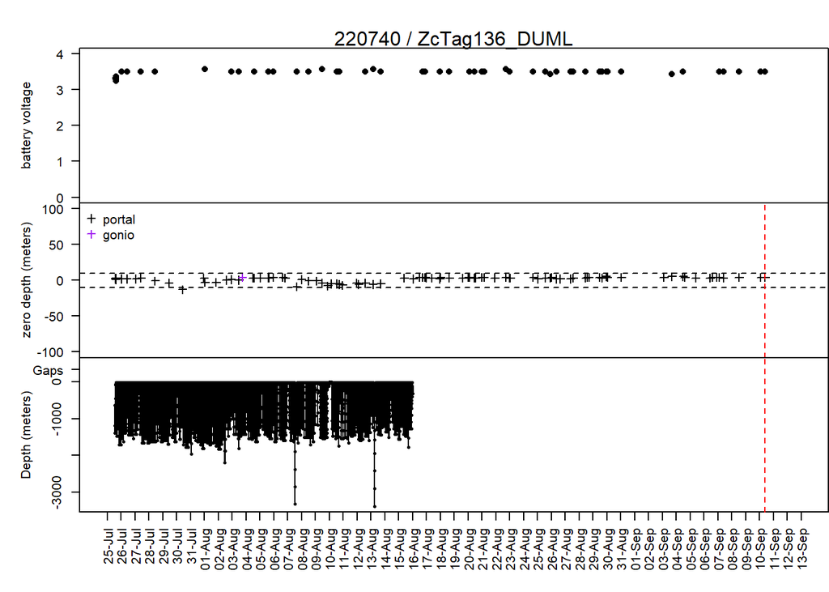

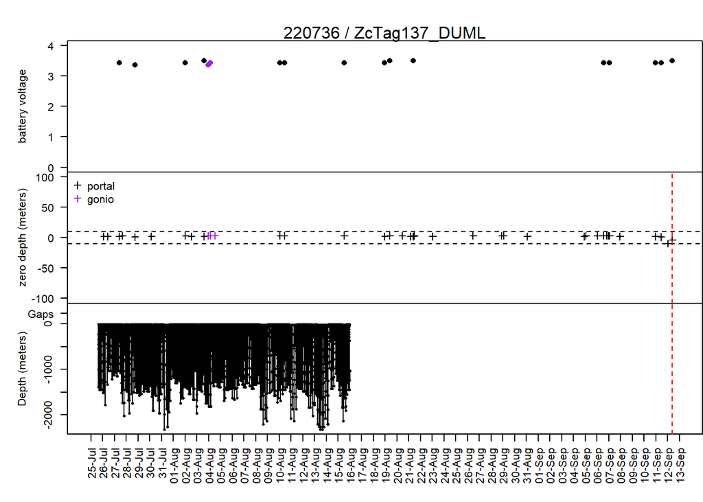

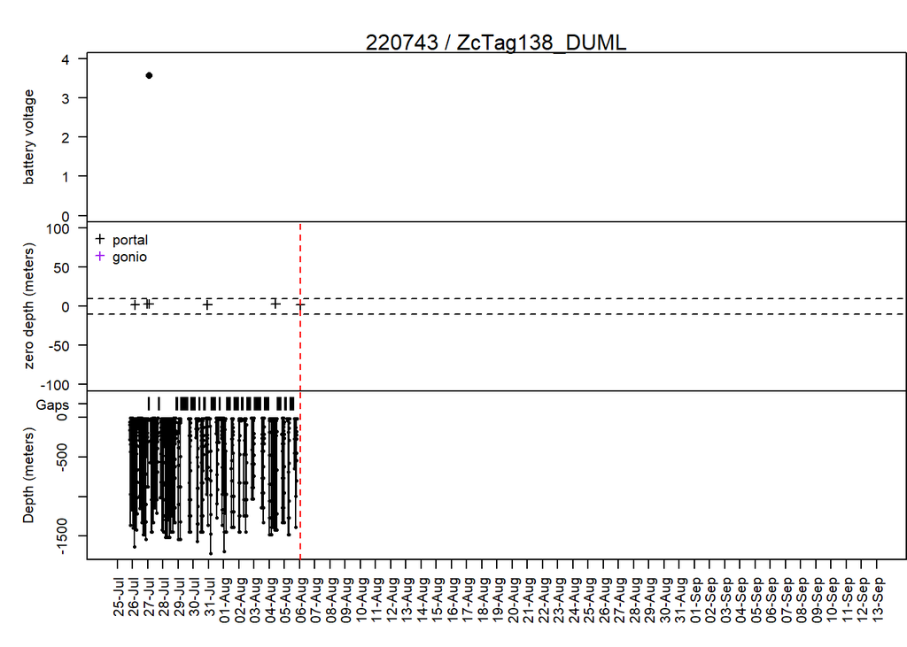

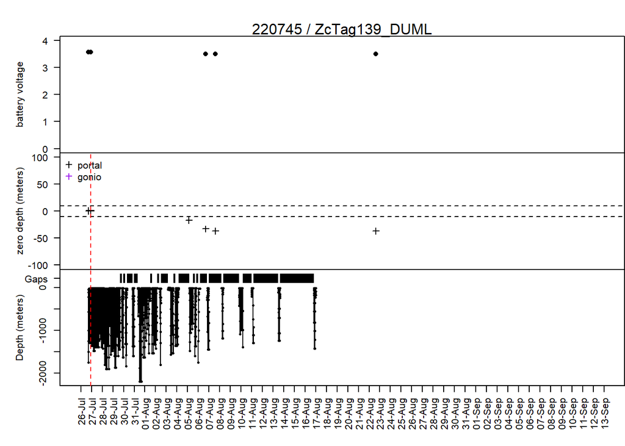

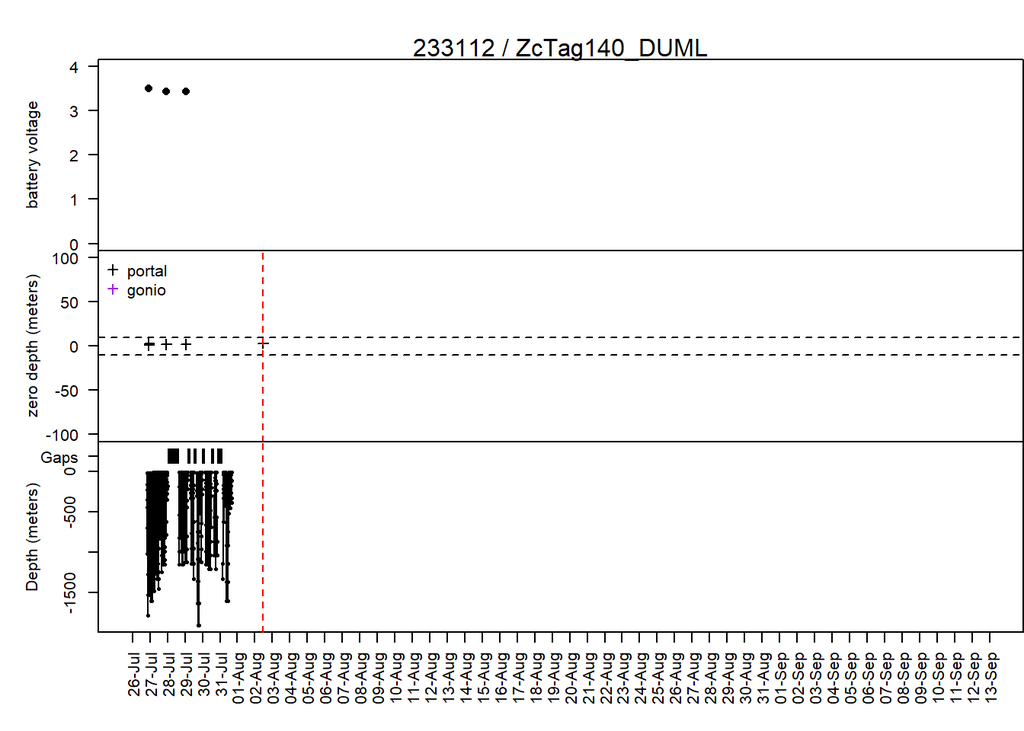

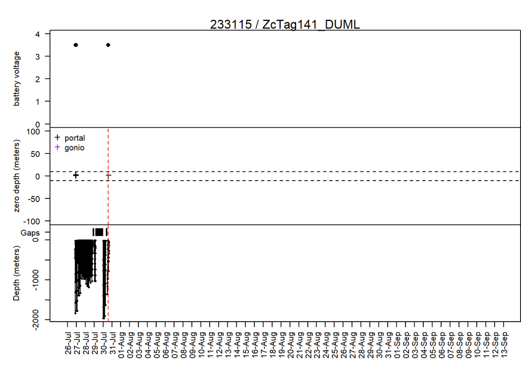

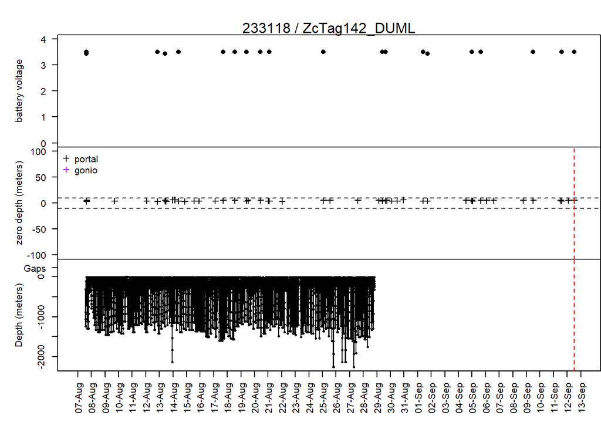

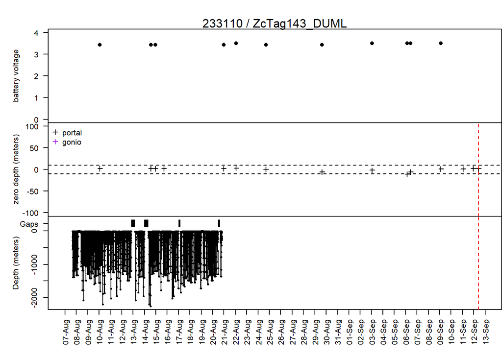

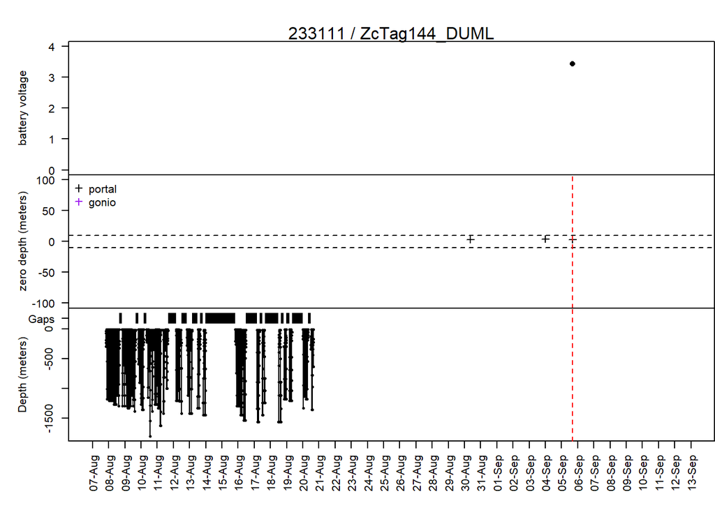

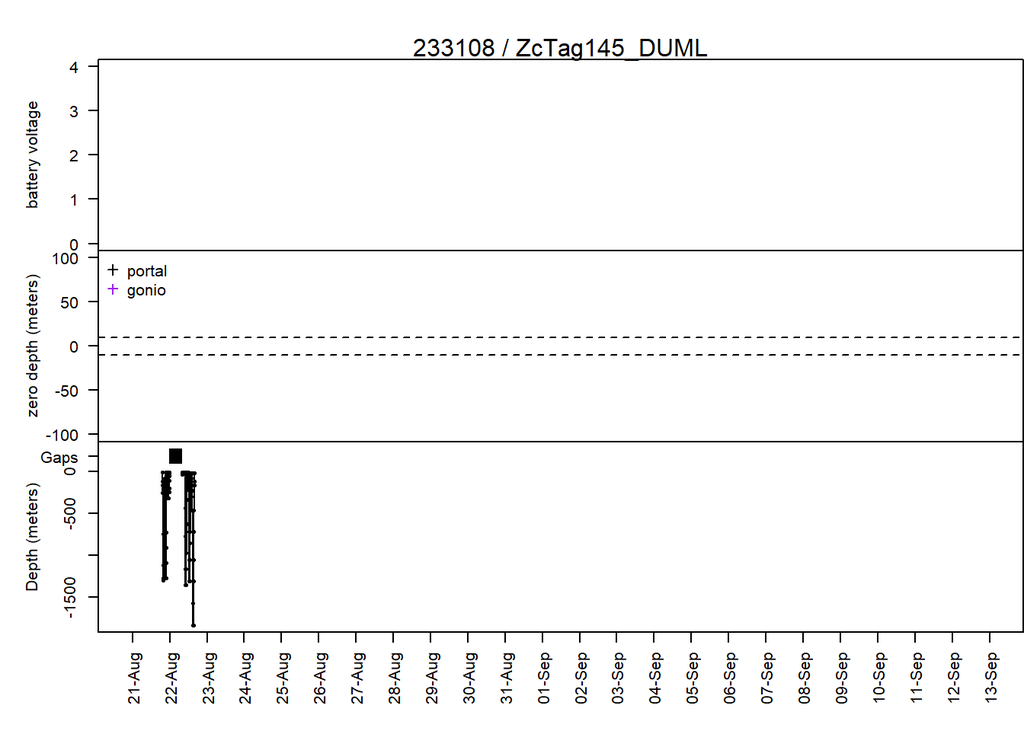

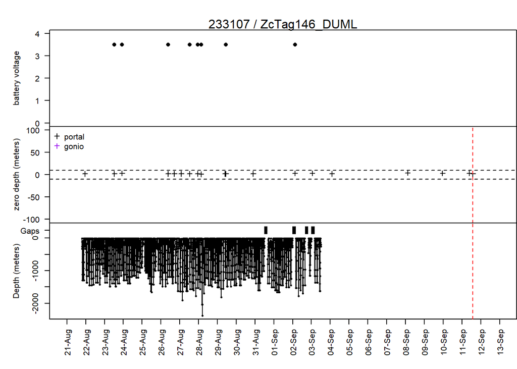

# 8 control cee

gonio hits in purple

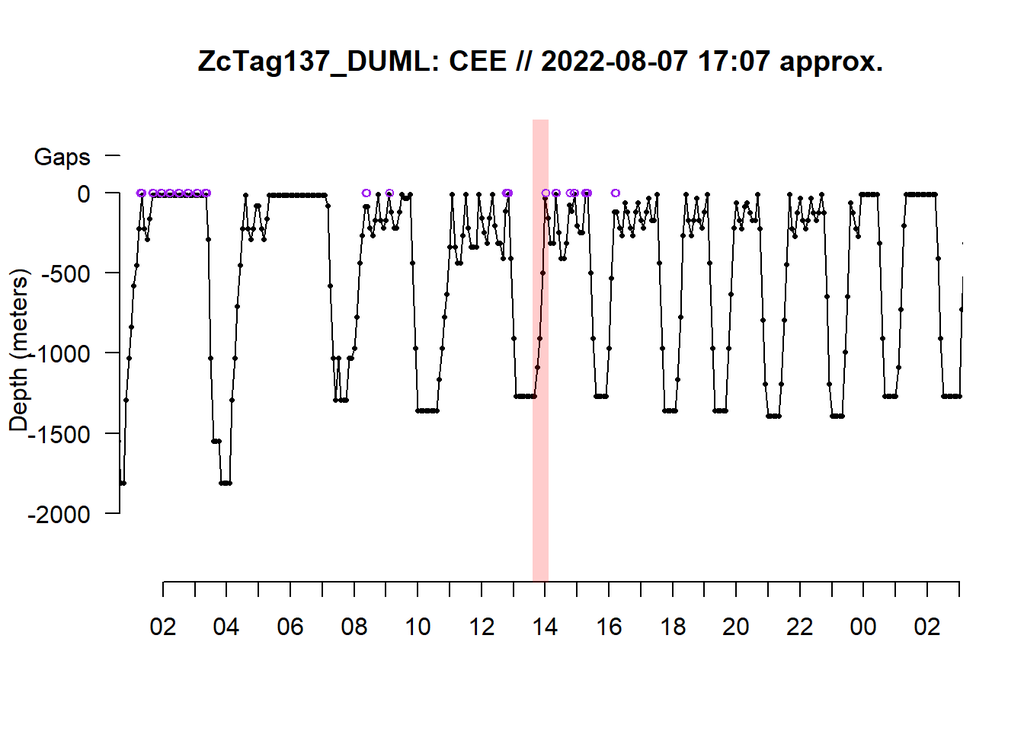

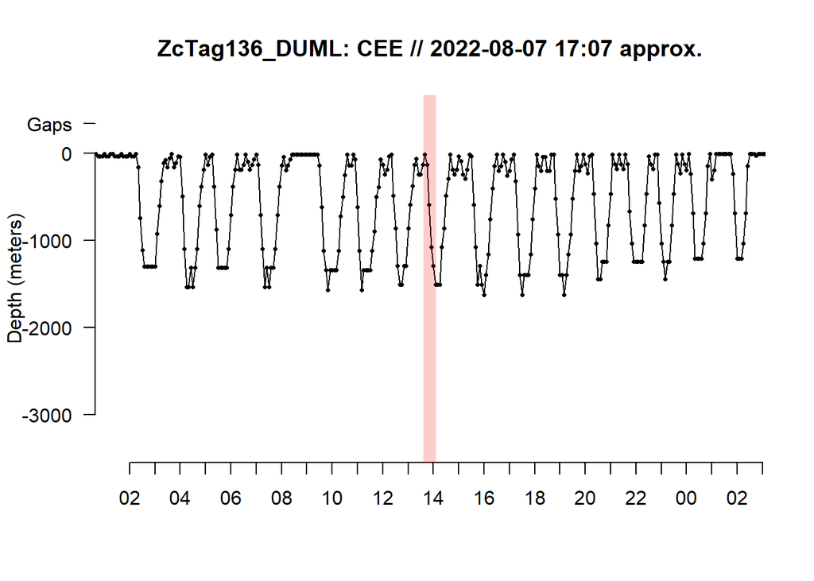

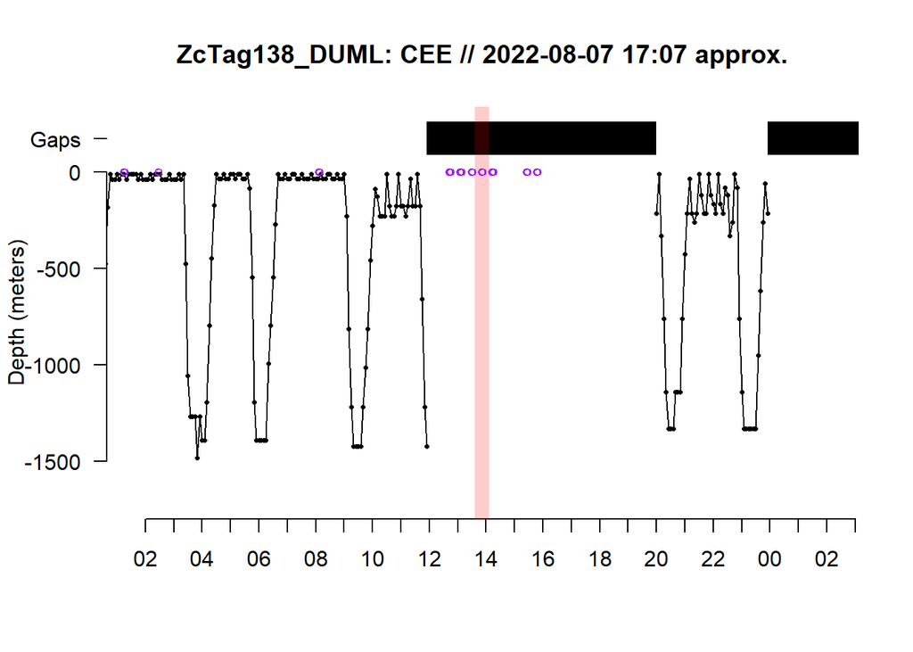

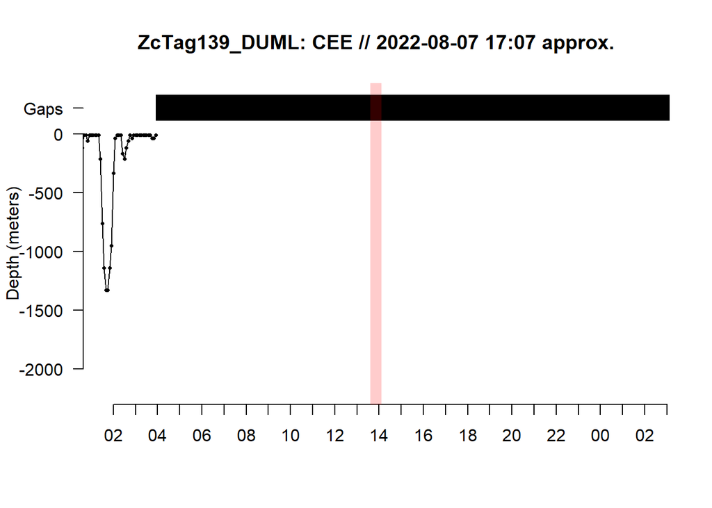

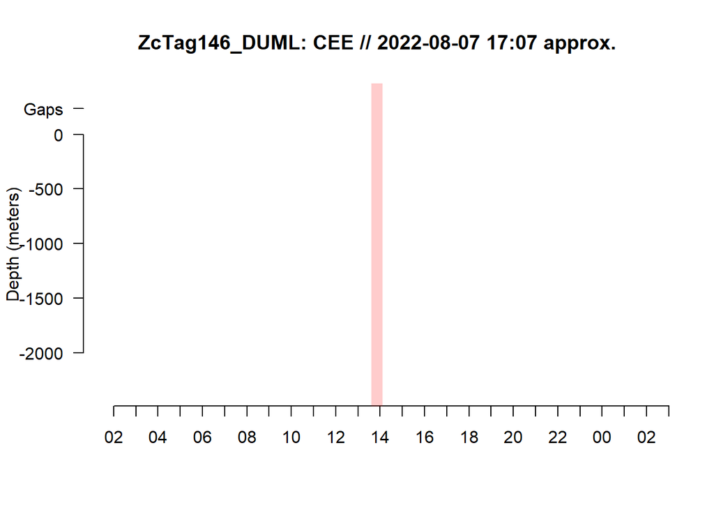

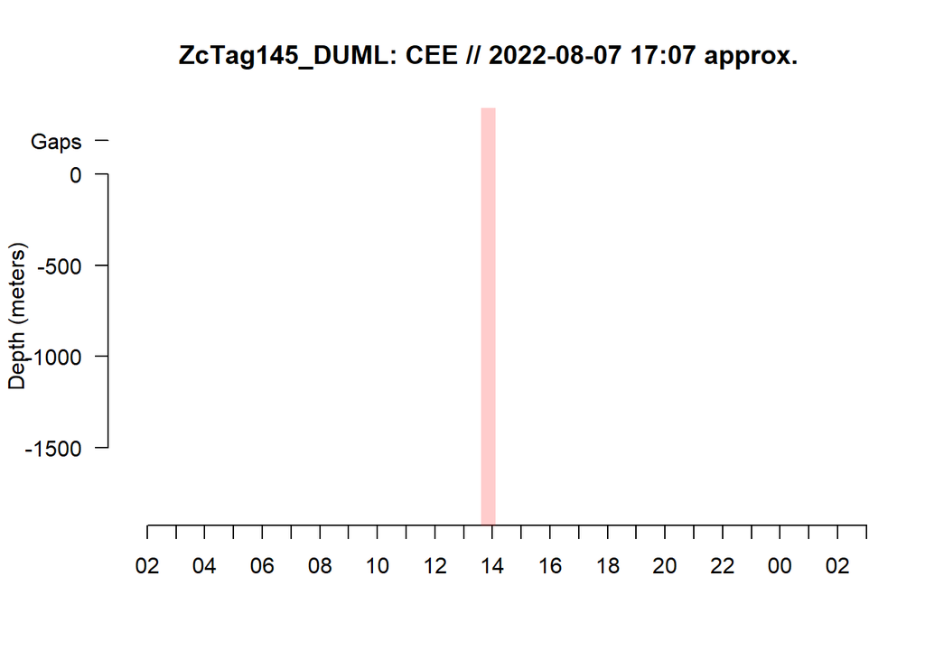

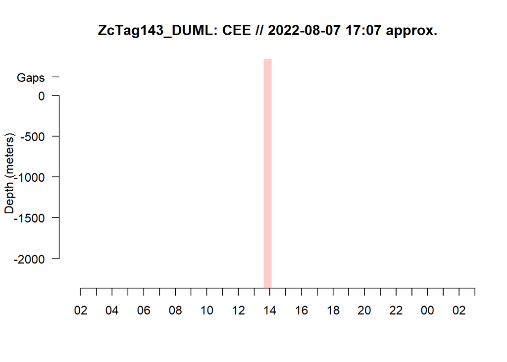

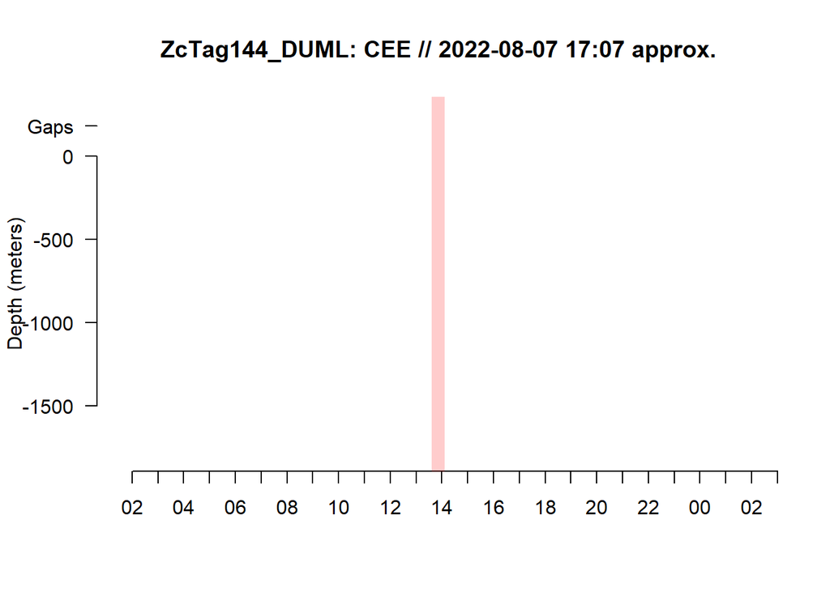

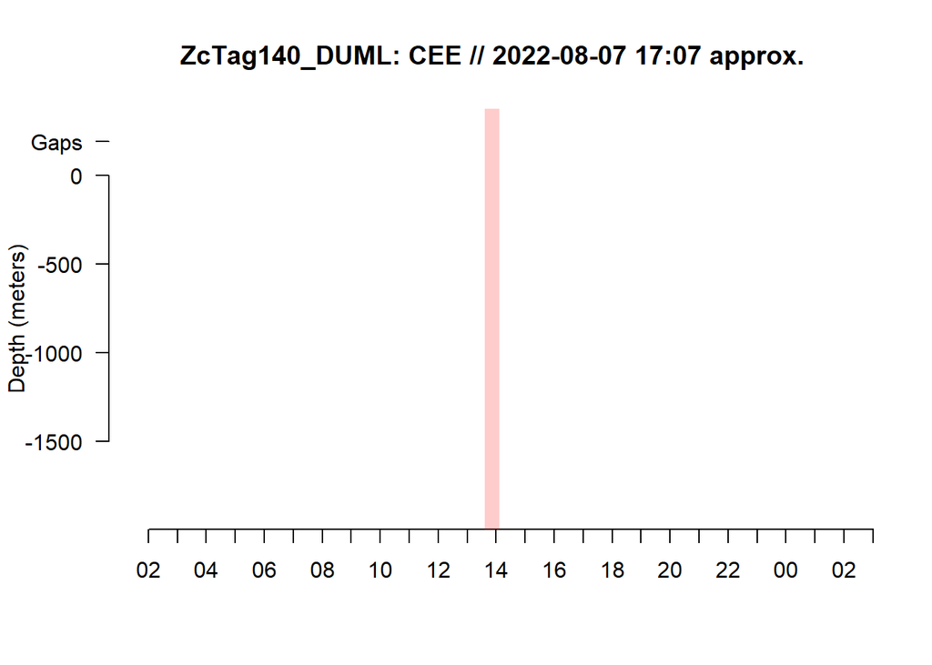

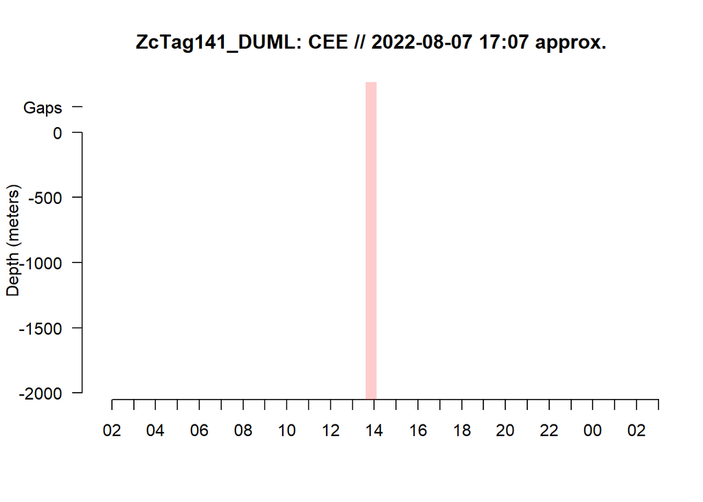

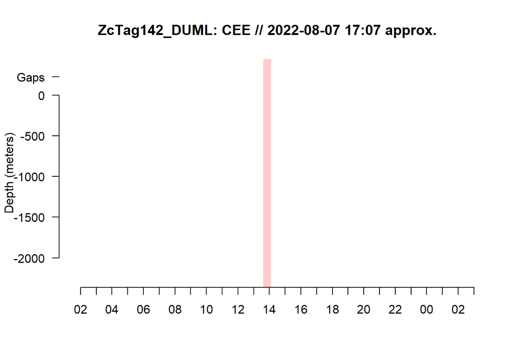

# 9 series message source plots

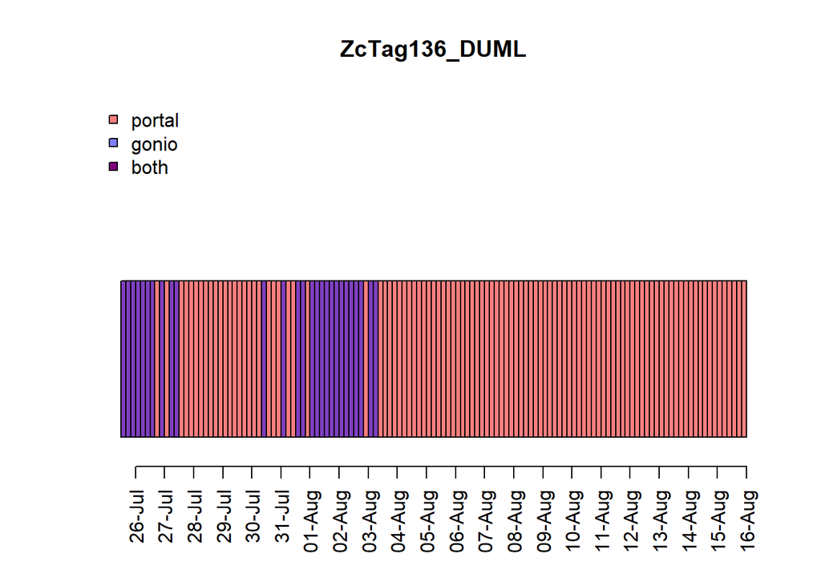

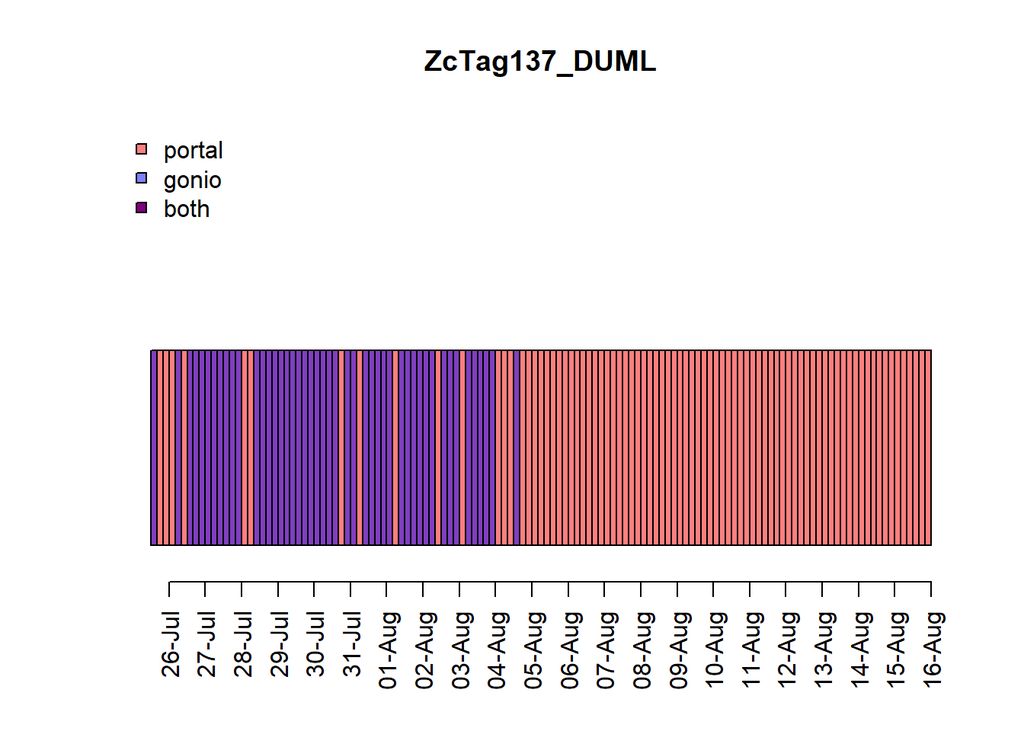

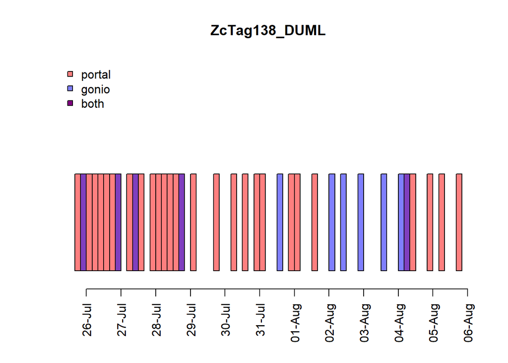

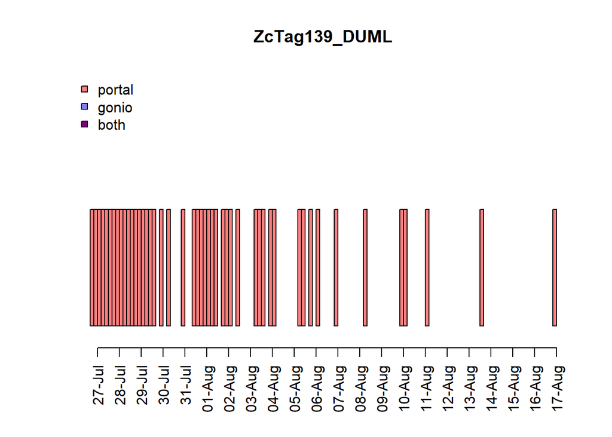

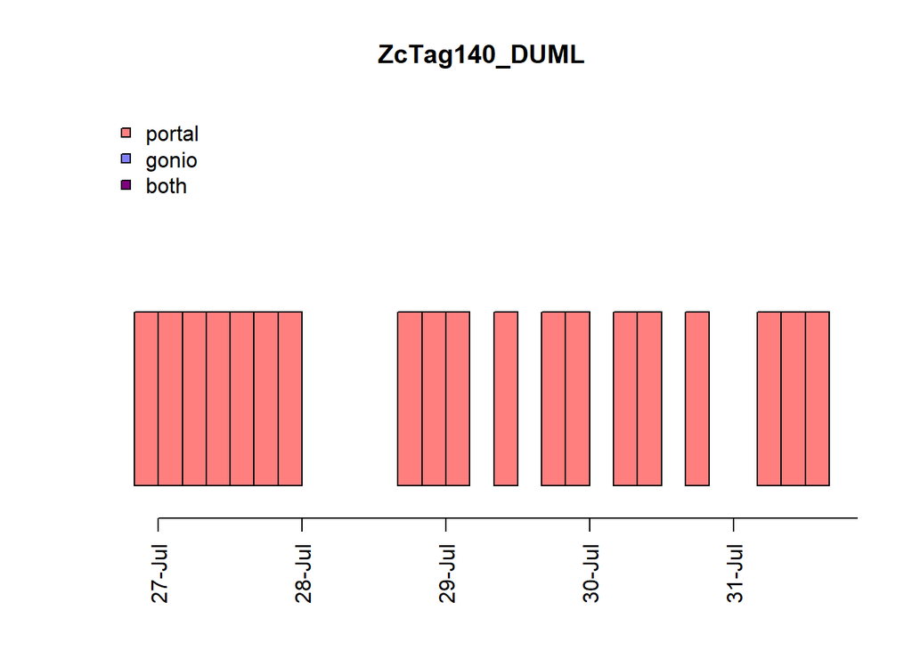

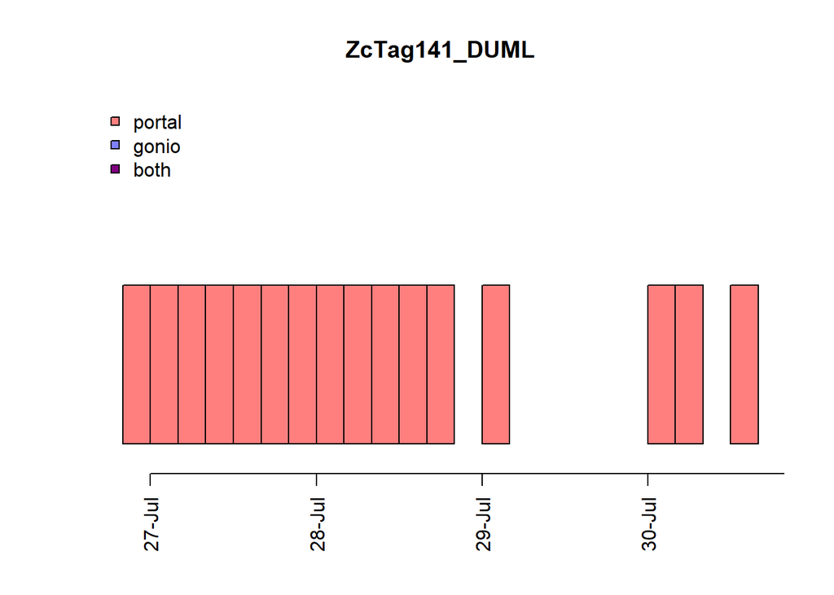

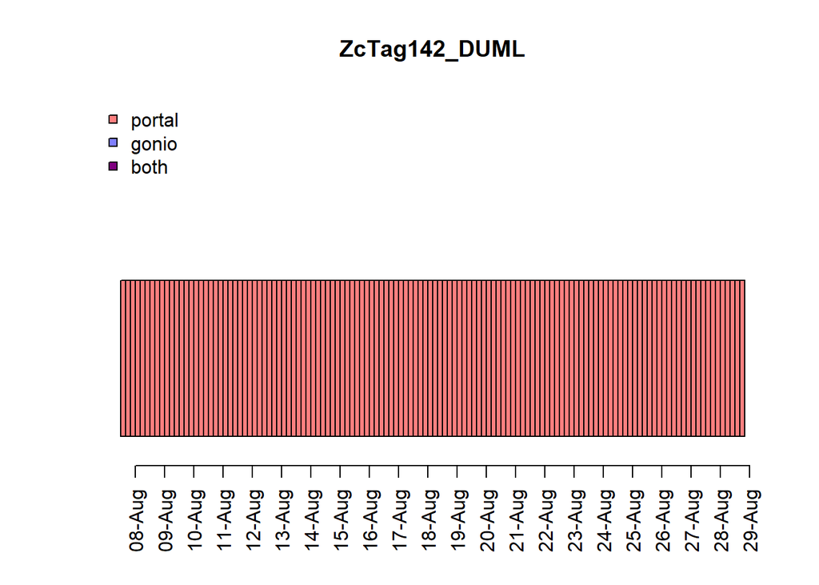